# 02 Lung Data Report

Heidi Steiner

2/22/2022

## Data Summaries

Easily print summary tables of your data with [`skimr`](https://docs.ropensci.org/skimr/)

```r
mockdata %>%
  skim()
```

Data summary

| Name | Piped data |
| --- | --- |
| Number of rows | 228 |
| Number of columns | 10 |
| _______________________ |  |
| Column type frequency: |  |
| factor | 6 |
| numeric | 4 |
| ________________________ |  |
| Group variables | None |

**Variable type: factor**

| skim_variable | n_missing | complete_rate | ordered | n_unique | top_counts |
| --- | --- | --- | --- | --- | --- |
| inst | 1 | 1.00 | FALSE | 18 | 1: 36, 12: 23, 13: 20, 3: 19 |
| status | 0 | 1.00 | FALSE | 2 | 2: 165, 1: 63 |
| sex | 0 | 1.00 | FALSE | 2 | 1: 138, 2: 90 |
| ph.ecog | 1 | 1.00 | FALSE | 4 | 1: 113, 0: 63, 2: 50, 3: 1 |
| ph.karno | 1 | 1.00 | FALSE | 6 | 90: 74, 80: 67, 70: 32, 100: 29 |
| pat.karno | 3 | 0.99 | FALSE | 8 | 90: 60, 80: 51, 70: 41, 100: 35 |

**Variable type: numeric**

| skim_variable | n_missing | complete_rate | mean | sd | p0 | p25 | p50 | p75 | p100 | hist |
| --- | --- | --- | --- | --- | --- | --- | --- | --- | --- | --- |
| time | 0 | 1.00 | 305.23 | 210.65 | 5 | 166.75 | 255.5 | 396.50 | 1022 | ▇▇▃▂▁ |
| age | 0 | 1.00 | 62.45 | 9.07 | 39 | 56.00 | 63.0 | 69.00 | 82 | ▂▅▇▇▃ |
| meal.cal | 47 | 0.79 | 928.78 | 402.17 | 96 | 635.00 | 975.0 | 1150.00 | 2600 | ▃▇▅▁▁ |
| wt.loss | 14 | 0.94 | 9.83 | 13.14 | -24 | 0.00 | 7.0 | 15.75 | 68 | ▁▇▃▁▁ |

but this is not super reader friendly. …we can improve table output with `kable()` from the [`knitr`](https://yihui.org/knitr/) package and `kable_styling()` from the [`kableExtra`](https://haozhu233.github.io/kableExtra/) package.

I used the option `font_size = 9` to reduce the size of the text as well

```r
mockdata %>%
  skim() %>%
  knitr::kable() %>%
  kable_styling(font_size = 9)
```

| skim_type | skim_variable | n_missing | complete_rate | factor.ordered | factor.n_unique | factor.top_counts | numeric.mean | numeric.sd | numeric.p0 | numeric.p25 | numeric.p50 | numeric.p75 | numeric.p100 | numeric.hist |
| --- | --- | --- | --- | --- | --- | --- | --- | --- | --- | --- | --- | --- | --- | --- |
| factor | inst | 1 | 0.9956140 | FALSE | 18 | 1: 36, 12: 23, 13: 20, 3: 19 | NA | NA | NA | NA | NA | NA | NA | NA |
| factor | status | 0 | 1.0000000 | FALSE | 2 | 2: 165, 1: 63 | NA | NA | NA | NA | NA | NA | NA | NA |
| factor | sex | 0 | 1.0000000 | FALSE | 2 | 1: 138, 2: 90 | NA | NA | NA | NA | NA | NA | NA | NA |
| factor | ph.ecog | 1 | 0.9956140 | FALSE | 4 | 1: 113, 0: 63, 2: 50, 3: 1 | NA | NA | NA | NA | NA | NA | NA | NA |
| factor | ph.karno | 1 | 0.9956140 | FALSE | 6 | 90: 74, 80: 67, 70: 32, 100: 29 | NA | NA | NA | NA | NA | NA | NA | NA |
| factor | pat.karno | 3 | 0.9868421 | FALSE | 8 | 90: 60, 80: 51, 70: 41, 100: 35 | NA | NA | NA | NA | NA | NA | NA | NA |
| numeric | time | 0 | 1.0000000 | NA | NA | NA | 305.232456 | 210.645543 | 5 | 166.75 | 255.5 | 396.50 | 1022 | ▇▇▃▂▁ |
| numeric | age | 0 | 1.0000000 | NA | NA | NA | 62.447368 | 9.073457 | 39 | 56.00 | 63.0 | 69.00 | 82 | ▂▅▇▇▃ |
| numeric | meal.cal | 47 | 0.7938596 | NA | NA | NA | 928.779006 | 402.174708 | 96 | 635.00 | 975.0 | 1150.00 | 2600 | ▃▇▅▁▁ |
| numeric | wt.loss | 14 | 0.9385965 | NA | NA | NA | 9.831776 | 13.139902 | -24 | 0.00 | 7.0 | 15.75 | 68 | ▁▇▃▁▁ |

If you’re like me and the NAs in this output are a deal breaker, try splitting the factor variables from the numeric variables so there are fewer columns to report!

The `.$factor` function will filter just the factor variables from the skim list.

```r
mockdata  %>%
  skim_to_list() %>%
  .$factor %>%
  knitr::kable( caption = 'Factor Variables') %>%
  kable_styling( font_size = 9)
```

Factor Variables

| skim_variable | n_missing | complete_rate | ordered | n_unique | top_counts |
| --- | --- | --- | --- | --- | --- |
| inst | 1 | 0.9956140 | FALSE | 18 | 1: 36, 12: 23, 13: 20, 3: 19 |
| status | 0 | 1.0000000 | FALSE | 2 | 2: 165, 1: 63 |
| sex | 0 | 1.0000000 | FALSE | 2 | 1: 138, 2: 90 |
| ph.ecog | 1 | 0.9956140 | FALSE | 4 | 1: 113, 0: 63, 2: 50, 3: 1 |
| ph.karno | 1 | 0.9956140 | FALSE | 6 | 90: 74, 80: 67, 70: 32, 100: 29 |
| pat.karno | 3 | 0.9868421 | FALSE | 8 | 90: 60, 80: 51, 70: 41, 100: 35 |

and `.$numeric` function will filter just the numeric variables from the skim list.

```r
mockdata  %>%
  skim_to_list() %>%
  .$numeric %>%
  knitr::kable( caption = 'Numeric Variables') %>%
  kable_styling( font_size = 9)
```

Numeric Variables

| skim_variable | n_missing | complete_rate | mean | sd | p0 | p25 | p50 | p75 | p100 | hist |
| --- | --- | --- | --- | --- | --- | --- | --- | --- | --- | --- |
| time | 0 | 1.0000000 | 305.232456 | 210.645543 | 5 | 166.75 | 255.5 | 396.50 | 1022 | ▇▇▃▂▁ |
| age | 0 | 1.0000000 | 62.447368 | 9.073457 | 39 | 56.00 | 63.0 | 69.00 | 82 | ▂▅▇▇▃ |
| meal.cal | 47 | 0.7938596 | 928.779006 | 402.174708 | 96 | 635.00 | 975.0 | 1150.00 | 2600 | ▃▇▅▁▁ |
| wt.loss | 14 | 0.9385965 | 9.831776 | 13.139902 | -24 | 0.00 | 7.0 | 15.75 | 68 | ▁▇▃▁▁ |

## Tables

We also often want to create basic (or not so basic) tables of results for our reports. Create quick frequency tables with [`janitor`](https://garthtarr.github.io/meatR/janitor.html)

```r
mockdata %>%
  tabyl(ph.ecog)
```

```
 ph.ecog   n     percent valid_percent
       0  63 0.276315789   0.277533040
       1 113 0.495614035   0.497797357
       2  50 0.219298246   0.220264317
       3   1 0.004385965   0.004405286
    <NA>   1 0.004385965            NA
```

`janitor` also has a mechanism to add frequency percentages and row totals to your tables

```r
mockdata %>%
  tabyl(ph.ecog) %>%
  adorn_totals("row") %>%
  adorn_pct_formatting()
```

```
 ph.ecog   n percent valid_percent
       0  63   27.6%         27.8%
       1 113   49.6%         49.8%
       2  50   21.9%         22.0%
       3   1    0.4%          0.4%
    <NA>   1    0.4%             -
   Total 228  100.0%        100.0%
```

and then you can add `kable()` and `kable_styling()` again to make it print how you need

```r
mockdata %>%
  tabyl(ph.ecog, sex) %>%
  knitr::kable(caption = 'ECOG performance score (0=good 5=dead) by Sex (Male=1 Female=2)',
               table.attr = "style='width:30%;'") %>%
  kable_styling()
```

ECOG performance score (0=good 5=dead) by Sex (Male=1 Female=2)

| ph.ecog | 1 | 2 |
| --- | --- | --- |
| 0 | 36 | 27 |
| 1 | 71 | 42 |
| 2 | 29 | 21 |
| 3 | 1 | 0 |
| NA | 1 | 0 |

## Figures

Often, you want to include results in the form of figures in your reports. [`ggplot2`](https://ggplot2.tidyverse.org/) makes plotting formulaic.

**Hint** I removed observations with ECOG scores of 3 based on the last table.

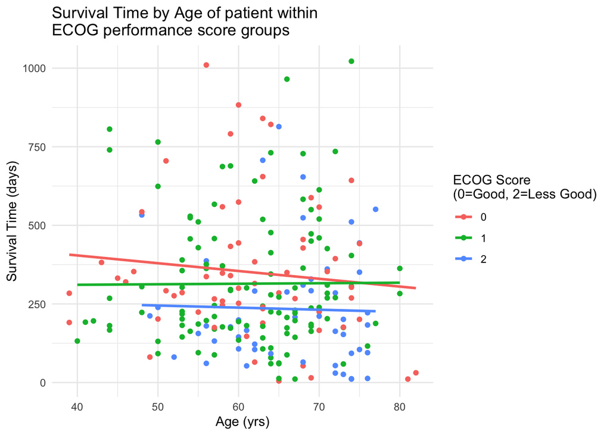

```r
p1 = mockdata %>%
  filter(ph.ecog != "3") %>%
  ggplot(aes(x = age, y = time, fill = ph.ecog, color = ph.ecog)) +
  geom_point() +
  geom_smooth(method = "lm", se = F) +
  labs(title = "Survival Time by Age of patient within \nECOG performance score groups",
       x = "Age (yrs)",
       y = "Survival Time (days)",
       fill = "ECOG Score \n(0=Good, 2=Less Good)",
       color = "ECOG Score \n(0=Good, 2=Less Good)")
p1
```

`ggplot2` is super dynamic and includes many ways to visualize your data

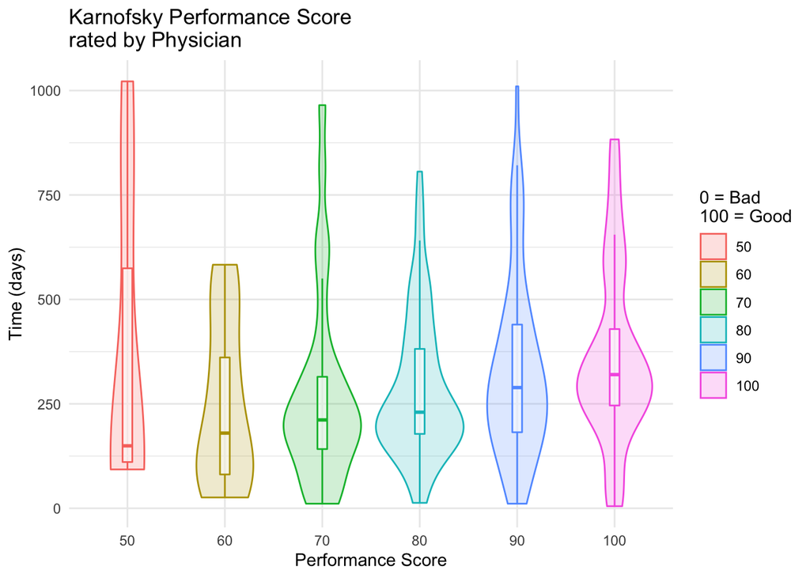

```r
p2 = mockdata %>%
  filter(ph.ecog != "3",
         !is.na(ph.karno)) %>%
  ggplot(aes(x = ph.karno, y = time)) +
  geom_violin(aes(fill = ph.karno,
                  color = ph.karno),
              alpha = .2) +
  geom_boxplot(aes(color = ph.karno),
               outlier.shape = NA,
               width = .1,
               alpha = .5,
               show.legend = F) +
  labs(fill = "0 = Bad\n100 = Good",
       color = "0 = Bad\n100 = Good",
       title = "Karnofsky Performance Score \nrated by Physician",
       x = "Performance Score",
       y = "Time (days)"
       )

p2
```

Or, perhaps you need to include a more domain specific plot. Google for your analysis and R (or tidyverse) and see if this already exists!

Here, I demonstrate visualizing a survival analysis with the `survival` and [`survminer`](https://rpkgs.datanovia.com/survminer/index.html) packages.

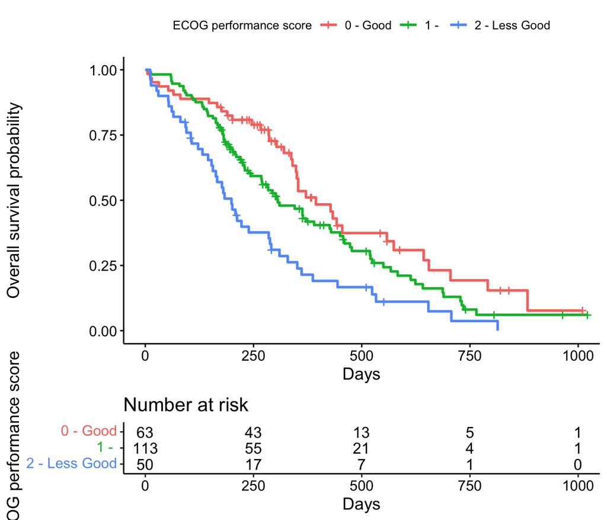

```r
p3 = ggsurvplot(
    fit = survfit(Surv(time, status) ~ ph.ecog, data = lung %>% filter(ph.ecog != "3")),
    xlab = "Days",
    ylab = "Overall survival probability",
    legend.lab = c("0 - Good", "1 - ", "2 - Less Good"),
    legend.title = "ECOG performance score",
    risk.table = T)
p3
```

Sometimes, you’ll want to combine multiple plots of different types such as the ones we’ve just created. [`cowplot`](https://cran.r-project.org/web/packages/cowplot/vignettes/introduction.html) (and `patchwork`) lets us combine multiple plots in a grid.

First, I align the top plots and then added the survival curve to the grid!

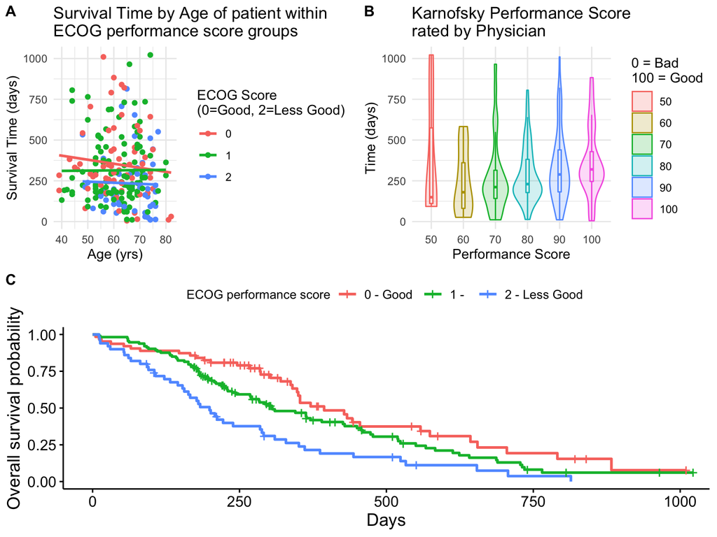

```r
cow1 = plot_grid(p1, p2,
          labels = c('A', 'B'),
          label_size = 12,
          ncol = 2)

plot_grid(cow1, p3$plot,
          label_size = 12,
          labels = c('', "C"),
          ncol = 1)
```

## Your Turn

#### 1.

Make this table print nicely when knitted

```r
mockdata %>%
  tabyl(ph.ecog, sex) %>%
  adorn_totals("row") %>%
  adorn_percentages("row") %>%
  adorn_pct_formatting(digits = 2) %>%
  adorn_ns()
```

#### 2.

Add variables to this typical [table one](https://thomaselove.github.io/432-notes/building-table-1.html#two-examples-from-the-new-england-journal-of-medicine) created with the [`aresenal`](https://mayoverse.github.io/arsenal/reference/arsenal.html) package

```r
library(arsenal)

tableby(ph.ecog ~ sex, data = mockdata) %>%
  summary()
```

|  | 0 (N=63) | 1 (N=113) | 2 (N=50) | 3 (N=1) | Total (N=227) | p value |
| --- | --- | --- | --- | --- | --- | --- |
| **sex** |  |  |  |  |  | 0.721 |
| 1 | 36 (57.1%) | 71 (62.8%) | 29 (58.0%) | 1 (100.0%) | 137 (60.4%) |  |
| 2 | 27 (42.9%) | 42 (37.2%) | 21 (42.0%) | 0 (0.0%) | 90 (39.6%) |  |

#### 3.

Add a `fig.path` in your chunk and `knit` again !

#### 4.

Add a histogram of the ages of the study participants in the plot grid for your report!

First, create, and save a histogram **HINT** check out the [`ggplot2` cheat sheet](https://www.rstudio.com/resources/cheatsheets/)

Then, add your plot to this grid copied from above.

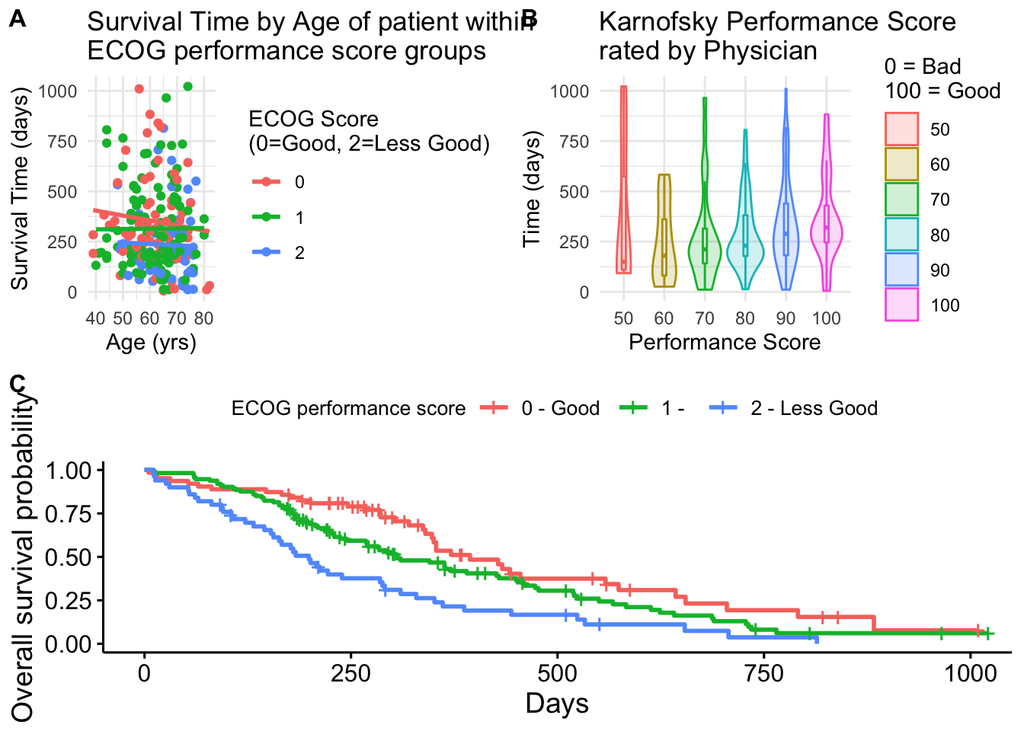

```r
plot_grid(cow1, p3$plot,
          label_size = 12,
          labels = c('', "C"),
          ncol = 1)
```